# Corporate Finance and Reality: Code File

```python
from datetime import date
today = date.today().strftime('%Y-%m-%d')
print("File was executed on {}".format(today))
```

```
File was executed on 2022-01-15
```

# Table of Contents

## Description

This file displays all of the results presented in "Corporate Finance and Reality" by John R. Graham.

Results are displayed in order of section. Results from appendices connected to each section are also displayed. For example, Section I below displays figures/tables from Section I in the text and from Appendix A2.

Whenever a figure was created in Python, it is displayed here. Many figures in the paper were finalized in Excel, so we only print the underlying data for those figures.

The underlying code to produce each figure or table are contained in .py files. For example, the file code/Demographics.py produces Figures 1, A2.1 and Table A2.I.

The results here were created using off-the-shelf Anaconda and should run via any relatively recent version of Anaconda and Jupyter. Nevertheless, we provide below all packages (and their versions) used to produce the results.

- Python 3.7.3
- Anaconda Navigator 2.0.3
- Jupyter Notebook 6.4.3
- pandas 1.1.3
- numpy 1.19.2
- matplotlib 3.3.2
- statsmodels 0.12.0
- PIL 8.3.1

There are two user-written functions, winsor.py and stacked_bar.py, located in the subfolder Functions, which are needed to produce the results.

## Section I: Data and Survey Methodology

Covers Section I and Appendix 2

- Figures 1 and A2.1
- Table A2.I

```
Displaying Figure 1:
```

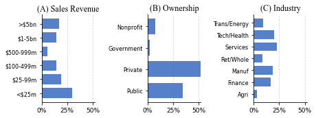

```
Displaying Figure A2.1:
```

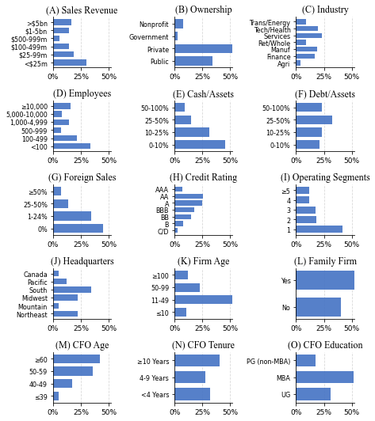

```
Displaying Table A2.I:
                 (1)      (2)      (3)      (4)           (5)      (6)  \
         % of Sample      25%      50%      75%   % of Sample      25%
≤ 5m            19.8      2.0      9.0     27.0          15.0      3.0
5-25m           16.2     31.0     59.0    100.0           7.2     26.0
25-100m         26.9     99.0    198.0    350.0          13.0     91.0
100m-1bn        21.3    425.0    925.0   1900.0          30.4    341.0
1-5bn            8.1   2150.0   5200.0  10000.0          21.4   2217.0
> 5bn            7.7  10000.0  35500.0  82500.0          12.9  10700.0

              (7)      (8)
              50%      75%
≤ 5m         12.0     35.0
5-25m        56.0     94.0
25-100m     162.0    266.0
100m-1bn    762.0   1700.0
1-5bn      4900.0   9100.0
> 5bn     23200.0  55000.0
```

```python
import Code.Demographics
```

## Section II: Corporate Investment, Capital Budgeting and the Cost of Capital

Covers Section II and Appendix 4

- Figures 2, 3, 4, A4.1, 5
- Table I and Table II

```
Displaying Figure 2
```

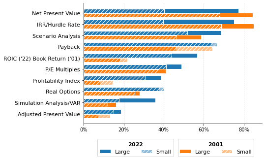

```
Displaying Table I, Panel A:
Variable                     Percent Always or Almost Always         \
Group                                            Large Firms
Survey                                                  2001   2022
N                                                        161    85
Net Present Value                                      84.52  77.38
IRR/Hurdle Rate                                        84.81  75.00
P/E Multiples                                          40.97  48.78
Payback                                                45.89  63.86
Profitability Index                                     8.03  38.75
ROIC ('22) Book Return ('01)                           18.18  56.79
Scenario Analysis                                      58.67  68.67
Simulation Analysis/VAR                                16.08  35.80
Real Options                                           28.03  37.50
Adjusted Present Value                                  7.30  18.75

Variable                                        2001 vs. 2022           \
Group                        Small Firms               Survey
Survey                              2001   2022          2001     2022
N                                    217    376           378      461
Net Present Value                  67.92  40.22          3.08  2.04***
IRR/Hurdle Rate                    68.72  39.67          3.09  2.10***
P/E Multiples                      37.50  41.24          1.89     1.92
Payback                            64.29  66.40          2.53  2.80***
Profitability Index                14.50  30.56          0.83  1.59***
ROIC ('22) Book Return ('01)       21.78  43.99          1.34  2.15***
Scenario Analysis                  46.38  51.78          2.31     2.38
Simulation Analysis/VAR            11.94  17.65          0.95  1.19***
Real Options                       25.63  40.28          1.47  1.90***
Adjusted Present Value             13.20  14.85          0.85     0.99

Variable
Group                        Small Firms          Large Firms
Survey                              2001     2022        2001     2022
N                                    217      376         161      85
Net Present Value                   2.83  1.80***        3.42   3.10**
IRR/Hurdle Rate                     2.86  1.89***        3.41   3.02**
P/E Multiples                       1.80     1.82        2.01     2.33
Payback                             2.72     2.80        2.25  2.82***
Profitability Index                 0.88  1.54***        0.75  1.81***
```

[output cut: 59 more lines]

```
Net Present Value                2.09
IRR/Hurdle Rate               2.21***
P/E Multiples                 2.04***
Payback                          2.81
Profitability Index              1.65
ROIC ('22) Book Return ('01)   2.23**
Scenario Analysis             2.48***
Simulation Analysis/VAR        1.27**
Real Options                     1.89
Adjusted Present Value         1.07**




Displaying Figure 3
```

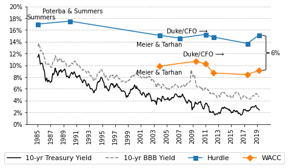

```
Displaying Table II
Demographic Variable        All Firms   Size          Public           \
Group                                  Small    Large     No      Yes
N                                 220    138      82     131      89
Hurdle Rate                     15.02  16.15  13.11**  16.03  13.52**
WACC                             9.04   9.10     8.95   8.95     9.17
Buffer (Hurdle Rate - WACC)      5.98   7.06   4.16**   7.08   4.35**

Demographic Variable        Growth Prospects          Pay Dividends         \
Group                                     No      Yes            No    Yes
N                                        101      112           132    88
Hurdle Rate                            13.37  16.62**         15.44  14.39
WACC                                    8.05  9.86***          9.00   9.11
Buffer (Hurdle Rate - WACC)             5.32     6.76          6.44   5.28

Demographic Variable        Leverage          Cash         \
Group                            Low   High    Low   High
N                                111    101    112    79
Hurdle Rate                    14.79  15.65  16.07  14.72
WACC                            8.79   9.28   8.94   9.17
Buffer (Hurdle Rate - WACC)     6.00   6.37   7.13   5.55

Demographic Variable        Financial Flexibility
Group                                          No    Yes
N                                             22     198
Hurdle Rate                                 15.18  15.00
WACC                                         9.48   8.99
Buffer (Hurdle Rate - WACC)                  5.70   6.01




Displaying data for Figure 4
                              Percent
Borrowing Costs              0.389381
Market Risk Premium          0.256637
Cost of Equity or Beta       0.221239
Type/Location of Investment  0.132743




Displaying data for Figure A4.1:
location       US/Canada    Europe      Asia  Latin America
hurdle_change
0               0.381643  0.258621  0.296774       0.211382
1               0.135266  0.189655  0.090323       0.097561
2               0.207729  0.172414  0.122581       0.252033
3               0.130435  0.172414  0.161290       0.182927
4               0.053140  0.068966  0.141935       0.056911
5               0.062802  0.068966  0.135484       0.052846
6+              0.028986  0.068966  0.051613       0.146341




Displaying Figure 5:
```

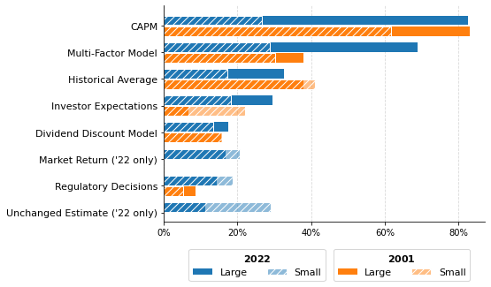

```
Displaying Table III, Panel A:
Panel                         Panel A: Cost of Equity, 2001 vs. 2022 Comparison  \
Variable                                        Percent Always or Almost Always
Group                                                               Large Firms
Survey                                                                     2001
N                                                                           126
CAPM                                                                       0.83
Multi-Factor Model                                                         0.38
Historical Average                                                         0.38
Investor Expectations                                                      0.07
Dividend Discount Model                                                    0.16
Market Return ('22 only)
Regulatory Decisions                                                       0.09
Unchanged Estimate ('22 only)

Panel                                                                  \
Variable                                               Score
Group                               Small Firms       Survey
Survey                         2022        2001  2022   2001     2022
N                               51          105   87     231      138
CAPM                           0.83        0.62  0.27   2.92  2.14***
Multi-Factor Model             0.69        0.30  0.29   1.56     1.81
Historical Average             0.33        0.41  0.17   1.72  1.20***
Investor Expectations          0.30        0.22  0.18   0.86    1.12*
Dividend Discount Model        0.17        0.16  0.13   0.91     0.76
Market Return ('22 only)       0.17              0.21            1.06
Regulatory Decisions           0.14        0.05  0.19   0.44  0.89***
Unchanged Estimate ('22 only)  0.11              0.29            1.21

Panel
Variable
Group                         Large Firms          Small Firms
Survey                               2001     2022        2001     2022
N                                     126      51          105      87
CAPM                                 3.27     3.20        2.49  1.53***
Multi-Factor Model                   1.70  2.62***        1.39     1.34
Historical Average                   1.65     1.51        1.80  1.03***
Investor Expectations                0.54  1.27***        1.22     1.04
Dividend Discount Model              0.87     0.92        0.96     0.67
Market Return ('22 only)                      0.95                 1.12
```

[output cut: 73 more lines]

```

Capital Spending                    Actual Above Forecast in 2019
Current Profits                                          0.153846
Demand for our Product                                   0.384615
Cash Holdings                                            0.192308
Expected Future Profits                                  0.346154
Economic Uncertainty                                     0.076923
Political Uncertainty                                    0.000000
International Trade/Tariffs                              0.192308
Access to Borrowing                                      0.192308
Planned Acquisition or Divestiture                       0.038462
Actions of Competitors                                   0.115385
Price/Availability of Capital                            0.076923
Borrowing Interest Rate                                  0.115385
Domestic GDP Growth                                      0.115385
```

```python
import Code.Capital_Budgeting

import Code.Hurdle_Rates

import Code.Cost_of_Equity

import Code.Reasons_for_Capx_Miss
```

## Section III: Corporate Planning and Internal Forecasts

Covers Section III and Appendices 5 and 6

```
Displaying data for Figure 7
question      Can reliably plan T years into the future               \
time period                          5 years ago (2013) Today (2018)
industry
Retail                                         3.023810     2.190476
Finance                                        4.000000     2.160000
Services                                       3.556818     2.238636
Tech                                           3.200000     1.566667
Manufacturing                                  2.980000     1.855000
Healthcare                                     3.666667     2.083333

question      Expected life of a new project
time period               5 years ago (2013) Today (2018)
industry
Retail                              5.166667     3.452381
Finance                             4.800000     3.040000
Services                            5.534091     4.150000
Tech                                6.933333     4.866667
Manufacturing                       6.086000     4.856000
Healthcare                          6.166667     4.416667




Displaying Figure 8:
```

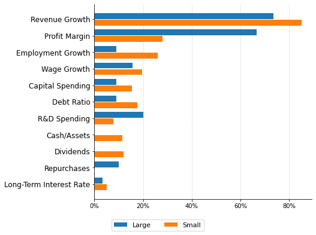

```
Displaying Figure 9:
```

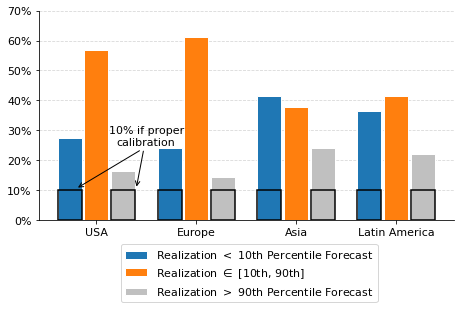

```
Displaying Figure 10:
```

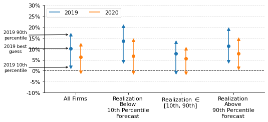

```
Displaying Figure 11:
```

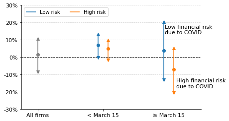

```
Displaying Data for Figure 12:
Sample        Pre-March 15, 2020
Variable                 Revenue Capital Spending Employment
accuracy_2019
All firms               0.060106         0.115822   0.036895
Low miss                0.066328         0.191233   0.051290
Accurate                0.017500         0.063750   0.013553
High miss               0.053778         0.062526   0.053846




Displaying data for Figure A5.1 Panel A:
                             Does your company conduct scenario analysis?
No                                                               0.376068
For specific projects                                            0.166667
For some divisions or units                                      0.141026
For the entire company                                           0.470085




Displaying data for Figure A5.1 Panel B:
                                         What type of scenario planning do you use?
Downside/base case/upside                                                  0.830986
Specific events (e.g. oil price spikes)                                    0.309859
Government regulation or legislation                                       0.169014




Displaying Figure A5.2:
```

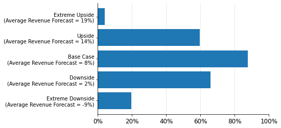

```
Displaying Table A5.I:
                        Negative Miss Prob Accurate Positive Miss Prob
Revenue Growth                       54.79     6.91              38.30
Wage Growth                          36.56    37.63              25.81
Patents                               8.70    84.35               6.96
Trademarks                           11.30    83.48               5.22
Dividends                            13.08    73.08              13.85
Repurchases                           7.38    86.89               5.74
Capital Spending                     39.31    37.93              22.76
R&D Spending                         17.60    60.00              22.40
Profit Margin                        40.91    20.45              38.64
Employment Growth                    34.44    38.33              27.22
Year-end Cash/Assets                 24.32    10.81              64.86
Year-end Debt Measure                39.53    34.88              25.58
Long-Term Interest Rate              67.92    16.35              15.72




Displaying data for Figure A5.3:
Question                            Actions Taken to Insulate Profitability  \
Group                                                                    No
group
Actual Revenue < Forecasted Revenue                                0.364706
Actual Revenue > Forecasted Revenue                                0.574468

Question
Group                                     Yes
group
Actual Revenue < Forecasted Revenue  0.635294
Actual Revenue > Forecasted Revenue  0.425532




Displaying data for Figure A6.1:
                                  All
GDP Growth (USA)             0.496503
Consumer Spending            0.412587
Commodity Prices             0.314685
Interest Rates               0.300699
Inflation                    0.216783
GDP Growth (Global)          0.209790
International Trade/Tariffs  0.195804
Currency Exchange Rates      0.132867
Infrastructure Spending      0.132867
Defense Spending             0.041958
```

```python
import Code.Planning_Horizons

import Code.Impact_of_Forecast_Errors

import Code.Revenue_Miscalibration_by_Industry

import Code.Impact_of_Miscalibration_on_Revenue_Distributions

import Code.Impact_of_Forecast_Errors_on_Firm_Plans

import Code.Scenario_Planning

import Code.Accuracy_of_Internal_Forecasts

import Code.Insulate_Profitability

import Code.Macro_Variables_Outcomes
```

## Section IV: Capital Structure

Covers Section IV and Appendix 7

- Figures 13, 14, 15, 16, 17, 18, 19, A7.1, A7.2, A7.3, A7.4, A7.5
- Tables IV, V, VI, VII, VIII

```
Displaying data for Figure 13:
                            Primary  Secondary  Tertiary       sum
Debt Metric         Size
Liabilities/ Assets Small  0.096525   0.158301  0.146718  0.090090
                    Large  0.036036   0.027027  0.027027  0.090090
Debt/Equity         Small  0.135135   0.077220  0.096525  0.153153
                    Large  0.018018   0.063063  0.072072  0.153153
Debt/Value          Small  0.034749   0.073359  0.061776  0.225225
                    Large  0.081081   0.036036  0.108108  0.225225
Debt/Assets         Small  0.185328   0.189189  0.146718  0.288288
                    Large  0.108108   0.054054  0.126126  0.288288
Interest Coverage   Small  0.150579   0.223938  0.193050  0.486486
                    Large  0.045045   0.225225  0.216216  0.486486
Credit Rating       Small  0.015444   0.054054  0.100386  0.639640
                    Large  0.153153   0.315315  0.171171  0.639640
Debt/EBITDA         Small  0.332046   0.158301  0.135135  0.738739
                    Large  0.486486   0.198198  0.054054  0.738739




Displaying Table IV:
Type               Percent Primary, Secondary or Tertiary                     \
Variable                                          Primary Secondary Tertiary
Group
N
Debt Metric
Debt/EBITDA                                         37.84     17.03    11.08
Interest Coverage                                   11.89     22.43    20.00
Debt/Assets                                         16.22     14.86    14.05
Credit Rating                                        7.30     16.31    14.16
Liabilities/Assets                                   7.84     11.89    11.08
Debt/Equity                                         10.00      7.30     8.92
Debt/Value                                           4.86      6.22     7.57

Type               Conditional on Company Characteristics                  \
Variable                                             Size          Public
Group                                               Small    Large     No
N                                                     263      111    251
Debt Metric
```

[output cut: 199 more lines]

```
We set a timetable to bring down our debt ratio  71.67     63.77
We set a timetable to bring up our debt ratio    55.56    38.24*

Variable                                        Financial Flexibility
Group                                                              No      Yes
N                                                                 41       305
We set an upper limit on our debt ratio                         48.78  65.57**
We set a lower limit on our debt ratio                          26.83    36.96
We set a timetable to bring down our debt ratio                 80.00    69.11
We set a timetable to bring up our debt ratio                   36.36    48.62




Displaying Figure 16:
```

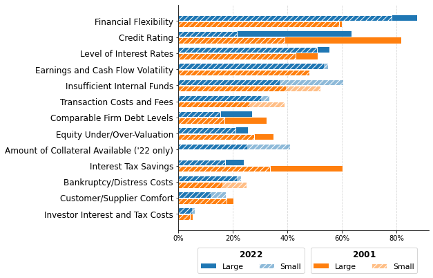

```
Displaying Table VII Panel A:
Panel                                     Panel A: Key Debt Factors, 2001 vs. 2022 Comparison  \
Variable                                                  Percent Important or Very Important
Group                                                                             Large Firms
Survey                                                                                   2001
N                                                                                         156
Financial Flexibility                                                                  59.87
Credit Rating                                                                          81.70
Level of Interest Rates                                                                50.99
Earnings and Cash Flow Volatility                                                      48.05
Insufficient Internal Funds                                                            39.33
Transaction Costs and Fees                                                             26.00
Comparable Firm Debt Levels                                                            32.24
Equity Under/Over-Valuation                                                            34.87
Amount of Collateral Available ('22 only)
Interest Tax Savings                                                                   60.26
Bankruptcy/Distress Costs                                                              16.11
Customer/Supplier Comfort                                                              20.13
Investor Interest and Tax Costs                                                         5.33

Panel                                                                \
Variable
Group                                            Small Firms
Survey                                      2022        2001   2022
N                                            107         211    262
Financial Flexibility                      87.38       59.02  78.17
Credit Rating                              63.46       38.83  21.43
Level of Interest Rates                    55.34       42.93  50.80
Earnings and Cash Flow Volatility          53.33       48.10  54.76
Insufficient Internal Funds                37.25       52.17  60.40
Transaction Costs and Fees                 30.39       38.94  33.33
Comparable Firm Debt Levels                26.92       16.91  15.54
Equity Under/Over-Valuation                25.49       27.72  20.99
Amount of Collateral Available ('22 only)  25.24              40.94
Interest Tax Savings                       24.04       33.65  17.13
Bankruptcy/Distress Costs                  21.36       25.12  23.11
Customer/Supplier Comfort                  11.76       17.70  17.36
Investor Interest and Tax Costs             4.95        4.39   6.10

Panel                                     Panel A: 2001 vs. 2022 Comparison  \
```

[output cut: 365 more lines]

```
Non-bank loans  Small (11%)  0.038462   0.423077   0.269231    0.192308
                Large (4%)   0.333333        NaN   0.333333         NaN
Lines of credit Small (38%)  0.475248   0.297030   0.178218    0.029703
                Large (25%)  0.233333   0.333333   0.433333         NaN

                             More than 10 years
Source          Size
Bonds           Small (4%)             0.166667
                Large (25%)            0.125000
Bank loans      Small (31%)            0.116279
                Large (19%)            0.050000
Non-bank loans  Small (11%)            0.076923
                Large (4%)             0.333333
Lines of credit Small (38%)            0.019802
                Large (25%)                 NaN
```

```python
import Code.Primary_Debt_Metric

import Code.Target_Debt_Ratio

import Code.Debt_Ratio_Limits

import Code.Key_Debt_Factors

import Code.Financial_Flexibility

import Code.Changed_Debt_Ratio

import Code.High_Leverage_Suboptimal_Decisions

import Code.External_Funding_Sources_Purposes

import Code.External_Funding_Rate_Maturity
```

## Section V: Payout

Covers Section V and Appendix 8

- Figures 20, 21, A8.1, A8.2
- Tables IX, A8.I

```
Displaying Figure 20:
```

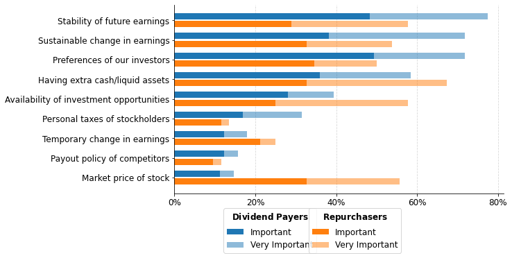

```
Displaying Table IX Panel A:
Panel                                    Panel A: Important Factors Driving Payout Decisions  \
Variable                                                 Percent Important or Very Important
Sample                                                                             All Firms
Payout Type                                                                             Rep.
N                                                                                         52
Stability of future earnings                                                          57.69
Preferences of our investors                                                          50.00
Sustainable change in earnings                                                        53.85
Having extra cash/liquid assets                                                       67.31
Availability of investment opportunities                                              57.69
Personal taxes of stockholders                                                        13.46
Temporary change in earnings                                                          25.00
Payout policy of competitors                                                          11.54
Market price of stock                                                                 55.77

Panel                                                                   \
Variable                                        Sub-Sample Comparisons
Sample                                                       All Firms
Payout Type                                Div.                   Rep.
N                                            89                     52
Stability of future earnings              77.53                   2.46
Preferences of our investors              71.91                   2.33
Sustainable change in earnings            71.91                   2.24
Having extra cash/liquid assets           58.43                   2.76
Availability of investment opportunities  39.33                   2.53
Personal taxes of stockholders            31.46                   0.94
Temporary change in earnings              17.98                   1.33
Payout policy of competitors              15.73                   0.98
Market price of stock                     14.61                   2.48

Panel                                                                    \
Variable
Sample                                            Public Firms
Payout Type                                  Div.         Rep.     Div.
N                                              89           32       33
Stability of future earnings               3.06**         2.57     3.13
Preferences of our investors               2.87**         2.45     2.61
Sustainable change in earnings             2.95**         2.32    3.00*
Having extra cash/liquid assets              2.55         3.03   1.97**
```

[output cut: 25 more lines]

```
N                                              56
Stability of future earnings                3.04*
Preferences of our investors              2.91***
Sustainable change in earnings             3.08**
Having extra cash/liquid assets              2.87
Availability of investment opportunities     2.21
Personal taxes of stockholders             2.19**
Temporary change in earnings                 1.67
Payout policy of competitors                 0.64
Market price of stock                     0.70***




Displaying Figure A8.1:
```

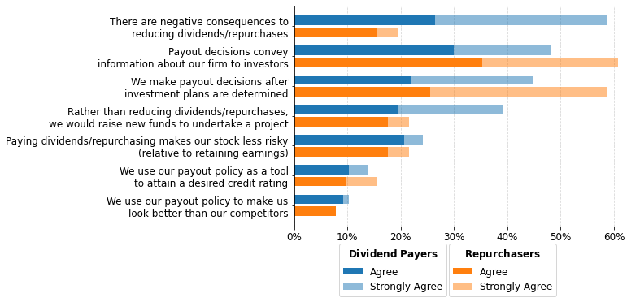

```
Displaying Figure A8.2:
```

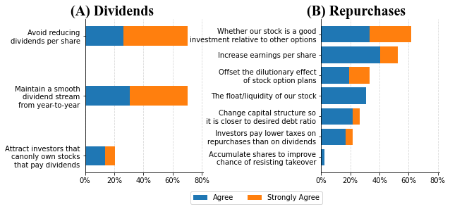

```
Displaying Figure 21:
```

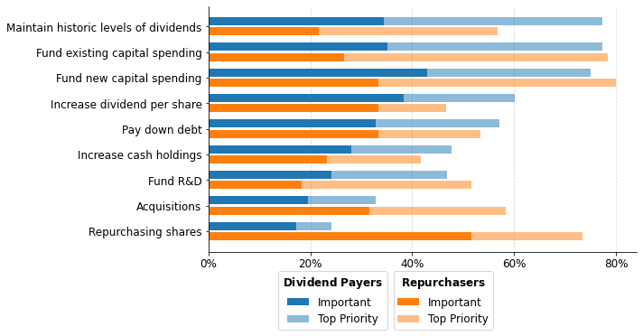

```
Displaying Table IX Panel B:
Panel                                 Panel B: How Do Companies Prioritize Capital Allocation of Funds?  \
Variable                                                              Percent Important or Top Priority
Sample                                                                                        All Firms
Payout Type                                                                                        Rep.
N                                                                                                   60
Maintain historic levels of dividends                                              56.67
Fund existing capital spending                                                     78.33
Fund new capital spending                                                          80.00
Increase dividend per share                                                        46.67
Pay down debt                                                                      53.33
Increase cash holdings                                                             41.67
Fund R&D                                                                           51.67
Acquisitions                                                                       58.33
Repurchasing shares                                                                73.33

Panel                                                                         \
Variable                                     Sub-Sample Comparisons
Sample                                                    All Firms
Payout Type                             Div.                   Rep.     Div.
N                                        128                    60       128
Maintain historic levels of dividends  77.34                   2.82   3.28**
Fund existing capital spending         77.34                   3.32     3.22
Fund new capital spending              75.00                   3.32     3.07
Increase dividend per share            60.16                   2.30    2.71*
Pay down debt                          57.03                   2.68     2.74
Increase cash holdings                 47.66                   2.43     2.46
Fund R&D                               46.88                   2.75     2.51
Acquisitions                           32.81                   2.80  2.22***
Repurchasing shares                    24.22                   2.91  1.85***

Panel                                                                   \
Variable
Sample                                Public Firms         Large Firms
Payout Type                                   Rep.    Div.        Rep.
N                                              39      49          30
Maintain historic levels of dividends         3.21    3.46        3.38
Fund existing capital spending                3.55    3.53        3.72
Fund new capital spending                     3.41    3.30        3.41
Increase dividend per share                   2.53    2.72        2.59
```

[output cut: 47 more lines]

```

                              2003-2020 (N = 2145)                      \

Speed of Adjustment  0.218726             0.217327  0.337204  0.000000
Target Payout        0.406488             0.242385  0.794644  0.001065
Adjusted R-Squared   0.498011             0.305947  0.262542  0.082252



Speed of Adjustment  0.052994  0.312393
Target Payout        0.132326  0.475081
Adjusted R-Squared   0.291031  0.489835

Note: see Stata file Lintner_regressions.do and lintner_regressions.log to see analysis for Table A8.I
This code just formats and prints regression results
```

```python
import Code.Payout_Factors

import Code.Capital_Allocation_Payout

import Code.Lintner
```

## Section VI: The Goal of the Firm

Covers Section VI

- Figures 22, 23

```python
import Code.Stakeholder_Interests
```

```
Displaying data for Figure 22:
loc_survey  North America 2010  North America 2020
bin_labels
0-20                  0.284553            0.156550
21-40                 0.451220            0.265176
41-60                 0.150407            0.485623
61-80                 0.089431            0.054313
81-100                0.024390            0.038339




Displaying data for Figure 23:
location         North America
N                   215.000000
Employees             0.623256
Customers             0.497674
Environment           0.213953
Creditors             0.195349
Local community       0.153488
Suppliers             0.130233
Government            0.069767
```